# HW 3

Author

Diana Tang

Libraries

```r
library(dplyr)
library(data.table)
library(ggplot2)
library(tidytext)
library(lubridate)
library(tidyverse)
library(leaflet)
library(dtplyr)
library(tm)
```

```r
if (!file.exists("pubmed.csv"))
  download.file(
    url = "https://raw.githubusercontent.com/USCbiostats/data-science-data/master/03_pubmed/pubmed.csv",
    destfile = "pubmed.csv",
    method   = "libcurl",
    timeout  = 60
    )
pubmed <- data.table::fread("pubmed.csv")
```

```r
saveRDS(pubmed, file = "pubmed.rds")
pubmedRDS <- readRDS("pubmed.rds")
str(pubmed)
```

```
Classes 'data.table' and 'data.frame':  3241 obs. of  2 variables:
 $ abstract: chr  "Background and aims: Many patients with coronavirus disease 2019 (COVID-19) have underlying cardiovascular (CV)"| __truncated__ "Introduction: Contradictory data have been reported on the incidence of stroke in patients with COVID-19 and th"| __truncated__ "This article aims at co…
 $ term    : chr  "covid" "covid" "covid" "covid" ...
 - attr(*, ".internal.selfref")=<externalptr>
```

### Text Mining Part 1

**Tokenize the abstracts with top 20 count**

```r
pubmedRDS %>%
  unnest_tokens(token,abstract) %>%
  count(token, sort = TRUE) %>%
  top_n(20, n)
```

```
       token     n
 1:      the 28126
 2:       of 24760
 3:      and 19993
 4:       in 14653
 5:       to 10920
 6:        a  8245
 7:     with  8038
 8:    covid  7275
 9:       19  7080
10:       is  5649
11:      for  5492
12: patients  4674
13:   cancer  3999
14: prostate  3832
15:      was  3315
16:     that  3226
17:     were  3226
18:       as  3159
19:     this  3158
20:      are  2833
```

**Remove stop words**

```r
pubmedRDS %>%
  group_by(term) %>%
  unnest_tokens(token, abstract) %>%
  anti_join(stop_words, by = c("token" = "word")) %>%
  count(token, sort = TRUE) %>%
  top_n(6, n)
```

```
# A tibble: 31 × 3
# Groups:   term [5]
   term            token            n
   <chr>           <chr>        <int>
 1 covid           covid         7275
 2 covid           19            7035
 3 prostate cancer cancer        3840
 4 prostate cancer prostate      3832
 5 covid           patients      2293
 6 preeclampsia    pre           2038
 7 preeclampsia    eclampsia     2005
 8 preeclampsia    preeclampsia  1863
 9 preeclampsia    women         1196
10 preeclampsia    pregnancy      969
# ℹ 21 more rows
```

When initially tokenizing the abstracts the top words were all articles or “stop words”. After removing the stop words, the top words and most common tokens were other medical terms. They top 5 common words for each respective term were as follows.

Covid: covid, 19, patients, disease, pandemic

Prostate Cancer: cancer, prostate, patients, treatment, disease

Preeclampsia: pre, eclampsia, preeclampsia, women, pregnancy

Cystic Fibrosis: fibrosis, cystic, cf, patients, disease

Meningitis: patients, meningitis, meningeal, csf, clinical

### Text Mining Part 2

**Tokenize abstracts into bigrams and visualize with ggplot2**

```r
top10 <- pubmedRDS %>%
  unnest_ngrams(bigram, abstract, n = 2) %>%
  count(bigram, sort = TRUE) %>%
  top_n(10, n)
top10
```

```
             bigram    n
 1:        covid 19 6969
 2:          of the 3883
 3:          in the 3418
 4: prostate cancer 3222
 5:   pre eclampsia 1854
 6:   patients with 1587
 7:        of covid 1519
 8:         and the 1154
 9:          to the 1061
10:     of prostate  870
```

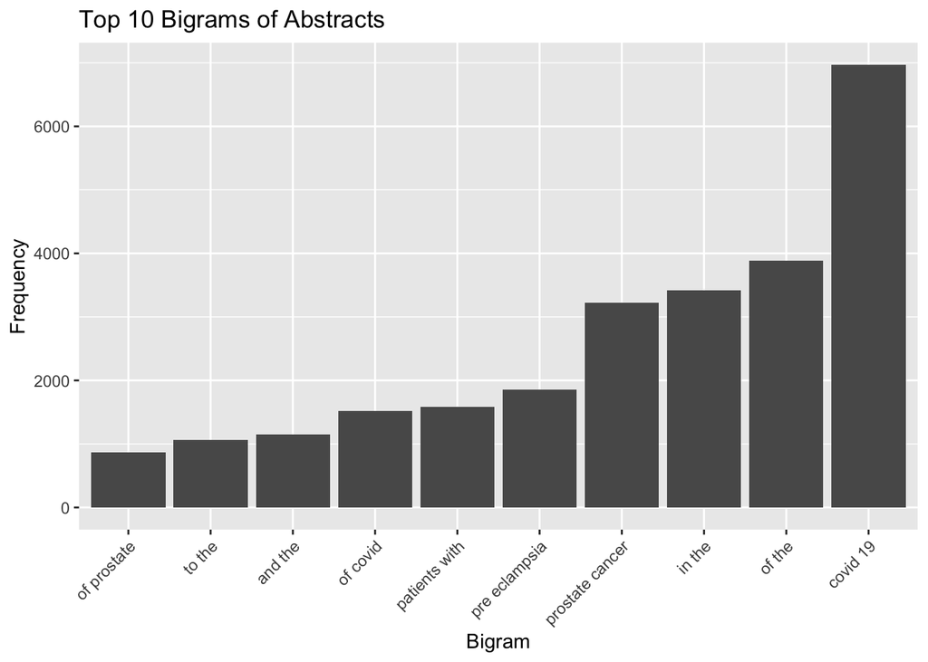

```r
ggplot(top10, aes(x = reorder(bigram, n), y = n)) +
  geom_bar(stat = "identity") +
  labs(x = "Bigram", y = "Frequency") +
  theme(axis.text.x = element_text(angle = 45, hjust = 1)) +
  ggtitle("Top 10 Bigrams of Abstracts")
```

### Text Mining Part 3

```r
tokenpubmed <- pubmedRDS %>%
  unnest_tokens(word, abstract)

tf <- tokenpubmed %>%
  group_by(term, word) %>%
  count() %>%
  ungroup()

idf <- tf %>%
  group_by(word) %>%
  summarise(docfreq = n())

tfidfdata <- tf %>%
   left_join(idf, by = "word") %>%
  mutate(tfidf = n * log2(n_distinct(term) / docfreq))

tfidfdata %>%
  group_by(term) %>%
  top_n(5, tfidf)
```

```
# A tibble: 25 × 5
# Groups:   term [5]
   term            word            n docfreq  tfidf
   <chr>           <chr>       <int>   <int>  <dbl>
 1 covid           coronavirus   647       1  1502.
 2 covid           cov           334       1   776.
 3 covid           covid        7275       1 16892.
 4 covid           pandemic      800       1  1858.
 5 covid           sars          372       1   864.
 6 cystic fibrosis cf            625       2   826.
 7 cystic fibrosis cftr           86       1   200.
 8 cystic fibrosis cystic        862       3   635.
 9 cystic fibrosis fibrosis      867       3   639.
10 cystic fibrosis sweat          83       1   193.
# ℹ 15 more rows
```

```r
unique(tokenpubmed$term)
```

```
[1] "covid"           "meningitis"      "prostate cancer" "cystic fibrosis"
[5] "preeclampsia"
```

The 5 tokens from each search term with the highest TF-IDF value are as follows with the TF-IDF value in paranetheses:

Covid: coronavirus (1502.2875), cov (775.5240), covid (16892.0269), pandemic (1857.5425), sars (863.7573)

Cystic Fibrosis: cf (826.2051), cftr (199.6858), cystic (635.2643), fibrosis (638.9492), sweat (192.72)

Meningitis: csf (272.3172), meningeal (508.5023), meninges (246.1244), meningitis (996.1072), pachymeningitis (345.9673)

Preeclampsia: eclampsia (4655.4658), gestational (443.4883), maternal (587.3616), preeclampsia (4325.7520), pregnancy (714.1197)

Prostate Cancer: androgen (708.1881), castration (343.6454), prostate (8897.6285), prostatectomy (499.2145), psa (654.7837)

Since the TF-IDF value measures how relevant a word is to a document, it would make sense that the words with higher TF-IDF value may not always be the most common words. Compared to the most common words, these words with the highest TF-IDF values seemed to be more pertinent to explaining the medical diagnoses within the abstracts.